# hw2

## Problem 4:

```r
mpg_1999 <- mpg %>%
  filter(year==1999)

mpg_2008 <- mpg %>%
  filter(year==2008)

print(summary(mpg_1999))
```

```
##  manufacturer          model               displ            year
##  Length:117         Length:117         Min.   :1.600   Min.   :1999
##  Class :character   Class :character   1st Qu.:2.200   1st Qu.:1999
##  Mode  :character   Mode  :character   Median :3.000   Median :1999
##                                        Mean   :3.281   Mean   :1999
##                                        3rd Qu.:4.000   3rd Qu.:1999
##                                        Max.   :6.500   Max.   :1999
##       cyl           trans               drv                 cty
##  Min.   :4.000   Length:117         Length:117         Min.   :11.00
##  1st Qu.:4.000   Class :character   Class :character   1st Qu.:14.00
##  Median :6.000   Mode  :character   Mode  :character   Median :17.00
##  Mean   :5.692                                         Mean   :17.02
##  3rd Qu.:6.000                                         3rd Qu.:19.00
##  Max.   :8.000                                         Max.   :35.00
##       hwy             fl               class
##  Min.   :15.00   Length:117         Length:117
##  1st Qu.:17.00   Class :character   Class :character
##  Median :25.00   Mode  :character   Mode  :character
##  Mean   :23.43
##  3rd Qu.:26.00
##  Max.   :44.00
```

```r
print(summary(mpg_2008))
```

```
##  manufacturer          model               displ            year
##  Length:117         Length:117         Min.   :1.800   Min.   :2008
##  Class :character   Class :character   1st Qu.:2.500   1st Qu.:2008
##  Mode  :character   Mode  :character   Median :3.600   Median :2008
##                                        Mean   :3.662   Mean   :2008
##                                        3rd Qu.:4.700   3rd Qu.:2008
##                                        Max.   :7.000   Max.   :2008
##       cyl           trans               drv                 cty
##  Min.   :4.000   Length:117         Length:117         Min.   : 9.0
##  1st Qu.:4.000   Class :character   Class :character   1st Qu.:13.0
##  Median :6.000   Mode  :character   Mode  :character   Median :17.0
##  Mean   :6.085                                         Mean   :16.7
##  3rd Qu.:8.000                                         3rd Qu.:20.0
##  Max.   :8.000                                         Max.   :28.0
##       hwy             fl               class
##  Min.   :12.00   Length:117         Length:117
##  1st Qu.:18.00   Class :character   Class :character
##  Median :24.00   Mode  :character   Mode  :character
##  Mean   :23.45
##  3rd Qu.:28.00
##  Max.   :37.00
```

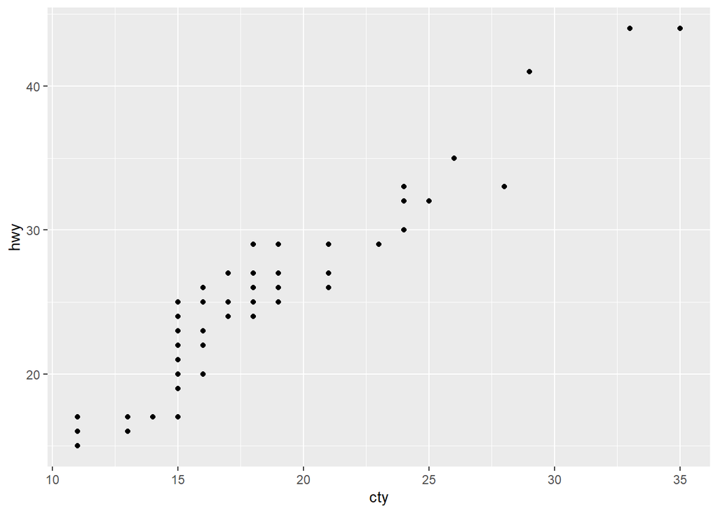

```r
mpg_1999 %>%
  ggplot(aes(x=cty, y=hwy)) +
  geom_point()
```

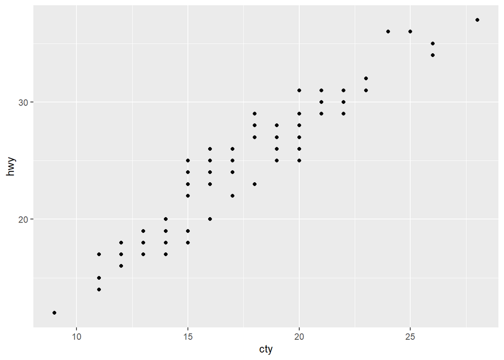

```r
mpg_2008 %>%
  ggplot(aes(x=cty, y=hwy)) +
  geom_point()
```

City mileage is worse at the extremes in 2008 (9-28 instead of 11-35), has a similar median, and has a smaller mean. However, the 3rd Qu. is larger in 2008, which speaks a little to the distribution of cty.

One large difference is seen in the scatter plots of cty/hwy – 2008 has a much more standard positive linear correlation between hwy/cty than 1999 does.

I think that data supports the notion that cars were more fuel efficient in general in 1999 – however, highway and city mileage are much more closely aligned in 2008.